# Alcohol vs Seat choice

Lelainy Saavedra

Fall 2020

## Our Goal is to answer this question Is there a difference between the alcohol consumed between the row

## you choose to sit in??

$H_0$: There is no difference in where you are seated and the amount of alcohol you consume.  
$H_A$: There is a difference in the location of where you are seated and the amount of alcohol you consume.

## Now with ggplot - first select the basic data

```r
basicCN <- ggplot(davisdata,aes(x=Seat,y=alcohol))
```

## Now add in boxplot

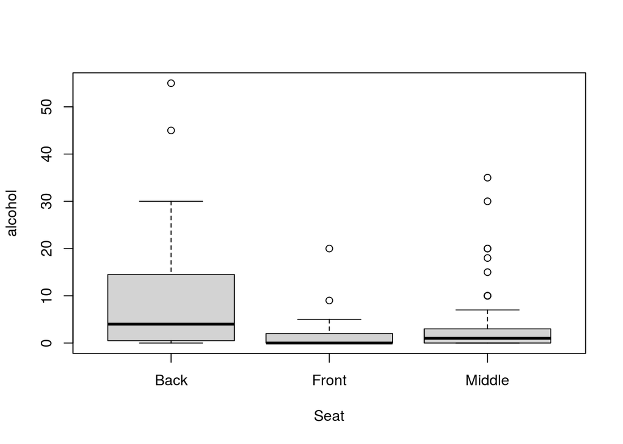

```r
boxplot(alcohol~Seat,data=davisdata)
```

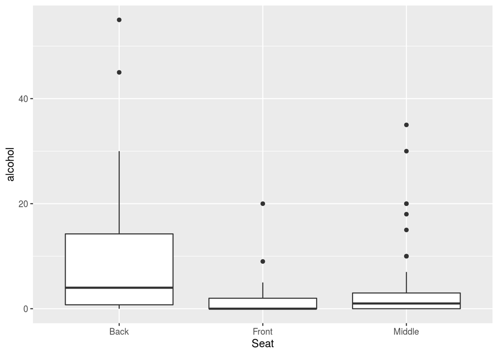

```r
basicCN + geom_boxplot()
```

### get fancy

```
## notch went outside hinges. Try setting notch=FALSE.
## notch went outside hinges. Try setting notch=FALSE.
```

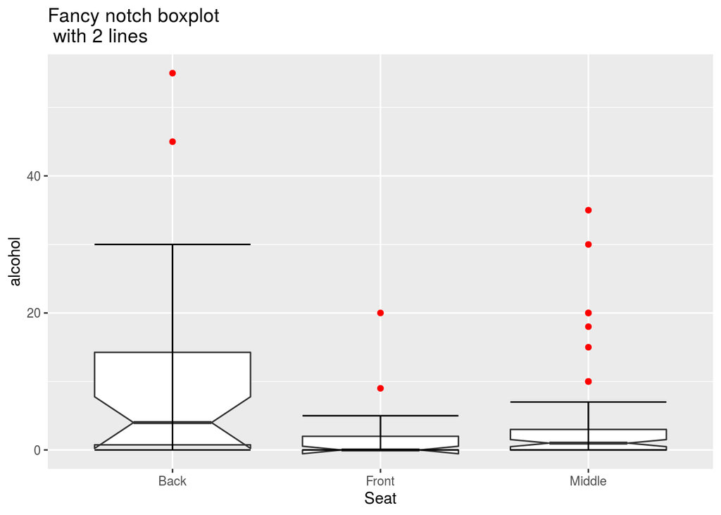

```r
basicCN + geom_boxplot(notch=TRUE,outlier.color = "red") + stat_boxplot(geom ='errorbar') + labs(title="Fancy notch boxplot \n with 2 lines")
```

## Numerical Summarys

```r
favstats(alcohol~Seat,data=davisdata)
```

```
##     Seat min   Q1 median    Q3 max     mean        sd  n missing
## 1   Back   0 0.75      4 14.25  55 9.625000 12.963970 32       0
## 2  Front   0 0.00      0  2.00  20 1.803030  3.878908 33       0
## 3 Middle   0 0.00      1  3.00  35 3.283133  6.353025 83       0
```

## Inferential Tests

```r
model1 <- aov(alcohol~Seat,data=davisdata)
summary.aov(model1)
```

```
##              Df Sum Sq Mean Sq F value   Pr(>F)
## Seat          2   1199   599.4   9.656 0.000116 ***
## Residuals   145   9001    62.1
## ---
## Signif. codes:  0 '***' 0.001 '**' 0.01 '*' 0.05 '.' 0.1 ' ' 1
```

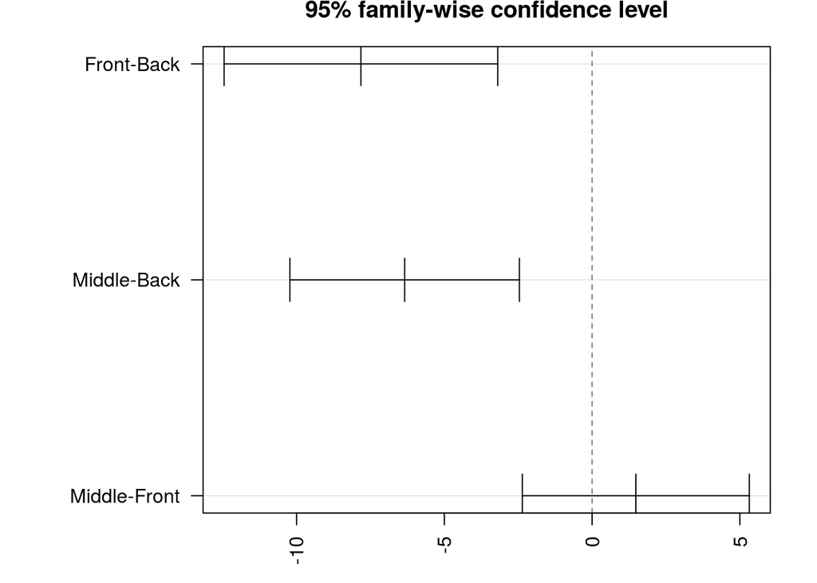

```r
#we specify the margins starting at the bottom and proceeding clockwise - thus 8.7 is the left side margin to hold the names of the factors
par(mar = c(3, 8.7, 2, 2))
plot(TukeyHSD(model1),las=2)
```

In this Turkey plot, we can see that the people who seat in the back consume more alcohol than the people who sit in the middle- front sections. It also shows that there is not really much of a difference between the people who sit in the front and the middle, BUT if you compare just front and back, people in the back consume way more alcohol.

## Conclusions

We reject the null Hypothesis because the P value is less than 0.05, and go for the alternative Hypothesis instead which states that there is a difference in where you are seated and the amount of alcohol you consume. Because the box plots and even when we got fancy we see that people in the back consume more alcohol than the people in the middle and front.